# 삼성디스플레이 2026 Q2 업데이트 — 2025 연간 확정 실적과 '느린 죽음'의 해부

Alpha Hunter Sector Report | 1Q26 보고서 후속편 · 내부 진단 × 재무 데이터 교차검증  
Alpha Hunter × Chimera AI · 2026-06-20

## 들어가며: 1Q26 보고서, 두 달 뒤의 답안지

> "지난 5월 1일 우리는 세 갈래 길을 그렸다. 6월, 2025년 연간 확정 실적과 내부 임원진의 육성이 그 지도가 맞았음을 확인해준다."

1Q26 섹터 보고서에서 삼성디스플레이(SDC)의 **세 가지 구조적 위기**(내부 저가 납품·중국 추격·산업 전환)를 진단하고, 2030년 세 시나리오(OLED 방어 45% / Glass 전환 35% / 치킨게임 패배 20%)를 제시했다.

이번 업데이트는 그 사이 확정된 **두 가지 새 데이터**를 반영한다:

1. **2025 연간 확정 실적** — 삼성전자 4분기 실적발표(1/29)로 DP부문·별도법인 수치가 모두 확정됐다.
2. **내부 임원 세미나 육성 기록** (2026-06-20) — "21~25년 매출 -20%, 영업이익 반토막, 앞으로 5년 더 어렵다"는 진단이 현장에서 나왔다.

결론부터: **시나리오 1(OLED 방어)의 유효기간이 데이터로 확인됐고, 시나리오 2(Glass 전환)의 시급성이 한층 커졌다.**

## I. 2025 연간 확정 실적: 두 개의 장부

### 1.1 재무 수치가 갈리는 이유

SDC 분석의 첫 함정은 **같은 회사에 숫자가 두 벌**이라는 점이다. 어느 쪽도 틀리지 않았다. 측정 단위가 다를 뿐이다.

**표 1. 삼성디스플레이 2022–2025: DP부문 vs 별도법인 (두 기준)**

| 연도 | DP부문 매출 | DP부문 영업이익 | DP부문 이익률 | 별도법인 매출 | 별도법인 영업이익 | 별도법인 순이익 |
| --- | --- | --- | --- | --- | --- | --- |
| 2022 | ~34조 | 5.9조 | 17.3% | 30.8조 | 4.40조 | 4.37조 |
| 2023 | ~30조 | 5.1조 | ~17% | 27.1조 | 3.77조 | 8.27조 |
| **2024** | **~30조** | **3.7조** | **12.7%** | **25.4조** | **2.46조** | **5.99조** |
| 2025 | ~30조 | 4.1조 | 13.8% | 26.0조 | 2.65조 | 5.52조 |

※ 2024년(굵게)이 두 기준 모두 바닥. DP부문=삼성전자 사업보고서(합산·환율 포함), 별도법인=삼성디스플레이㈜ 감사보고서(본업 기준).

왜 두 장부가 다른가

- **DP부문 (삼성전자 사업보고서)** — 합산·환율효과 포함. 시장과 증권사가 흔히 인용. 이익률이 더 높게 잡힌다.
- **별도법인 (삼성디스플레이㈜ 감사보고서)** — 내부거래 조정, 본업 기준. 더 보수적. 2024년 영업이익이 2.46조까지 떨어진 게 여기서 보인다.
- **결정적 단서:** 2023년 별도 영업이익 3.77조인데 순이익이 8.27조 — **본업(영업)보다 지분법·금융수익이 더 컸던 해**다. 영업의 질을 볼 땐 순이익이 아니라 영업이익을 봐야 한다.

→ 임원이 말한 **"영업이익 반토막"**은 별도법인 기준으로 정확하다: **4.40조(2022) → 2.46조(2024) = -44%.**

### 1.2 정점에서 바닥, 그리고 미약한 반등

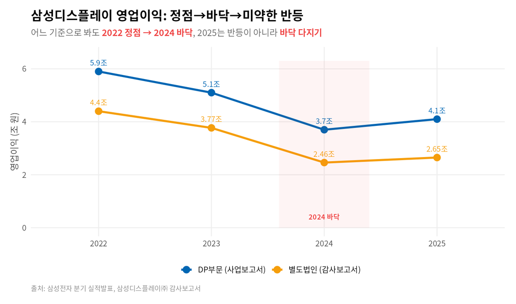

삼성디스플레이 연간 영업이익 추이 — 두 기준 동시 표시

2025 반등의 정체

DP부문 기준 2025년 영업이익이 3.7조→4.1조로 올랐지만, 이는 **구조적 개선이 아니다.** 경쟁사 아이폰 패널 공급 차질 반사이익과 환율이 만든 일시적 회복에 가깝다. 별도 기준으로는 2.46조→2.65조, 여전히 2022년 정점의 60% 수준이다. 임원진의 **"올해 PS 20%가 마지막"**이라는 발언이 이 미약함을 정확히 읽고 있다.

### 1.3 분기 해부: 계절성이라는 가면

연간 숫자는 SDC의 **구조적 계절성**을 숨긴다. 분기로 펼치면 진짜 그림이 보인다 — 아이폰 신제품이 나오는 **Q3에 피크, Q1에 바닥**. 1Q26 보고서의 분기 차트를 2025 확정치로 갱신했다.

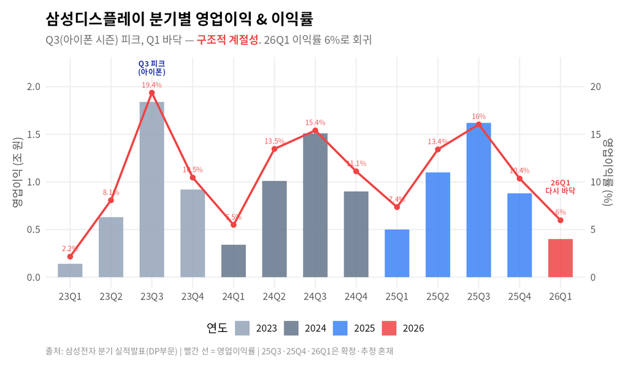

삼성디스플레이 분기별 영업이익 & 이익률 (2023-2026, DP부문)

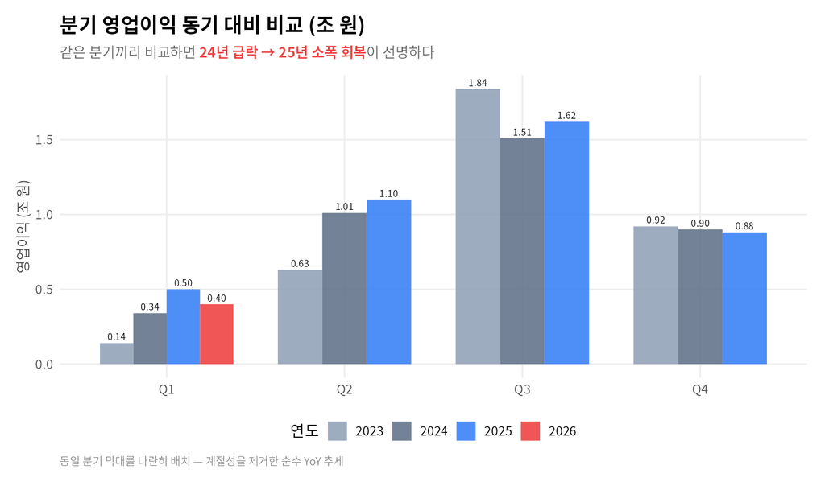

동기 대비(YoY) 분기 영업이익 — 계절성 제거 후 진짜 추세

분기가 말해주는 것

- **계절 진폭이 크다:** Q1 0.30.5조 vs Q3 1.51.8조 — 분기 이익이 **3~5배** 출렁인다. 애플 의존도의 직접 증거.
- **YoY로 보면 회복은 미약:** 24Q3 1.51조 → 25Q3 1.62조(+7%). 정점(23Q3 1.84조)엔 여전히 못 미친다.
- **26Q1 = 6% 이익률 회귀:** 1Q26 보고서가 짚은 "블라인드 6% 논란"의 분기다. 연간 평균(13.8%)이 가린 **바닥 분기의 민낯**.

## II. 점유율 양극화: 범용은 내주고, 프리미엄은 사수

1Q26 보고서의 "한국 점유율 62%, 2028~29 역전" 전망을, 이번엔 **시장 세그먼트별로 쪼개서** 본다. 핵심 발견: SDC의 운명은 하나가 아니라 **두 개로 갈라지고 있다.**

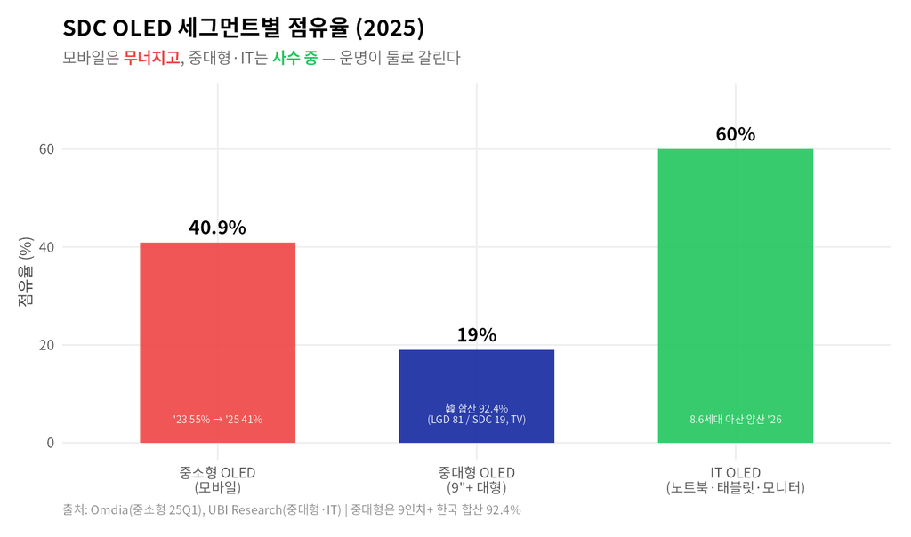

OLED 세그먼트별 SDC 포지션 — 같은 회사, 다른 전선

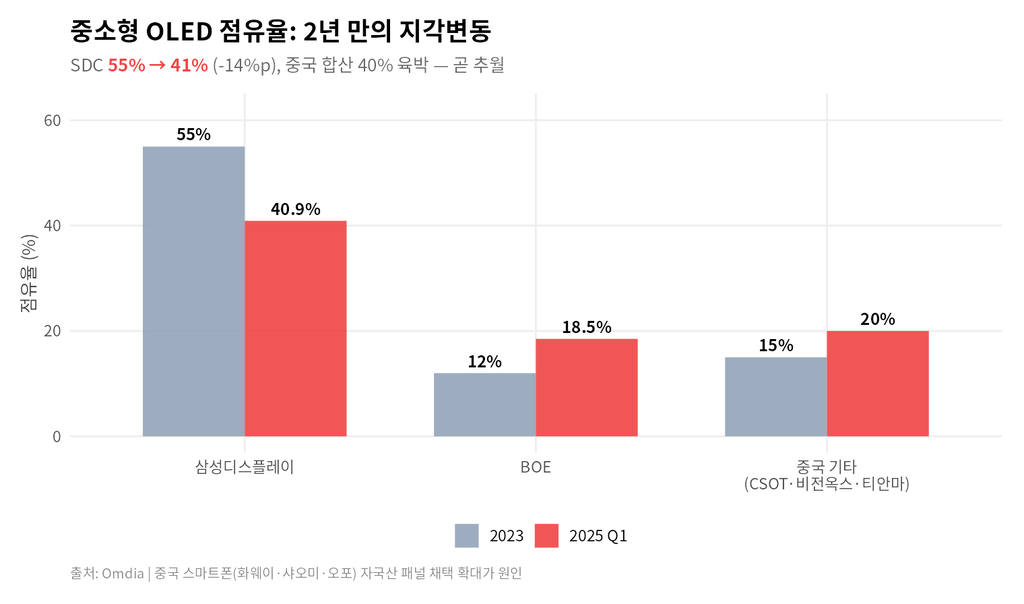

중소형 OLED: SDC의 가장 빠른 출혈

양극화의 전략적 의미

- **중소형(모바일):** 2년 -14%p, 중국 합산이 곧 SDC 추월. **여기는 이미 LCD의 길을 걷는다.** 매출 비중이 가장 큰 만큼 전사 이익률을 끌어내리는 주범.
- **중대형·IT:** 한국 92% 방어, 투-스택 탠덤 기술 해자로 중국 진입 차단. **여기가 마지막 프리미엄 보루.** 단, UBI는 **2028~29년 중국 생산능력 추월**을 경고 — 보루의 유효기간도 시한부.
- **시사점:** "OLED 방어" 전략은 전사가 아니라 **중대형·IT에 국한될 때만 유효**하다. 모바일 방어는 이미 실패한 전선이다.

## III. 내부 진단: 임원진이 육성으로 확인해준 '느린 죽음'

2026년 6월 20일 사내 AI 세미나에서 오간 임원진의 대화는, 1Q26 보고서가 외부 데이터로 추정한 위기를 **내부 당사자의 언어로** 재확인한다. 외부 분석과 내부 인식이 일치할 때, 진단의 신뢰도는 가장 높다.

**표 2. 내부 육성 진단 × 외부 데이터 교차검증 (2026-06-20 세미나)**

| 내부 진단 (육성) | 외부 데이터 검증 |
| --- | --- |
| 21~25년 매출 -20%, 영업이익 반토막 | 별도 영업이익 4.40조→2.46조 = **-44%** (정확) |
| 개발비 50% 증가, 5년 더 어렵다 | R&D 비용률 상승, 시나리오 1 마진 하락과 일치 |
| 올해 PS 20%가 마지막 | 2025 반등이 구조개선 아닌 일시 회복임을 내부도 인지 |
| 개발 캡파 2~3배인데 인력 그대로 → 연구소 수백 명 차출 | PoC 폭증(애플·구글·중화권) = 점유율 방어 비용 급증 |
| 4명이 PoC 60개 — 휴먼 에러 날 수밖에 없는 구조 | 품질 사고 증가 → QA 직군 수요 구조적 증가 |
| 회사-개인 동기화 단절, 후배 세대 변화 | 조직 피로 → AI 도입 압력의 근본 동인 |

"느린 죽음"의 메커니즘

임원진의 진단을 하나의 인과 사슬로 묶으면 **자기강화 악순환**이 보인다:

**점유율 하락 → 방어용 PoC 폭증(애플·구글·중화권) → 개발 캡파 초과 → 연구소·제주 인력 응급 차출 → 미래 혁신 R&D 공동화 → 차세대 기술 지연 → 점유율 추가 하락**

이 고리는 "지속은 가능하나 성장은 불가능한" 캐시카우의 전형이다. **생존하되 천천히 작아진다.** 끊는 방법은 고리 안에서 더 빨리 뛰는 게 아니라, **고리 밖(Glass Substrate)으로 나가는 것**뿐이다.

## IV. LG의 그림자: 그룹 통합이라는 진짜 리스크

1Q26 보고서가 다루지 않은 새 변수. 같은 세미나에서 임원들이 **부러움 섞어** 언급한 LG 사례는, SDC의 가장 큰 리스크가 **기술이 아니라 그룹 거버넌스**임을 시사한다.

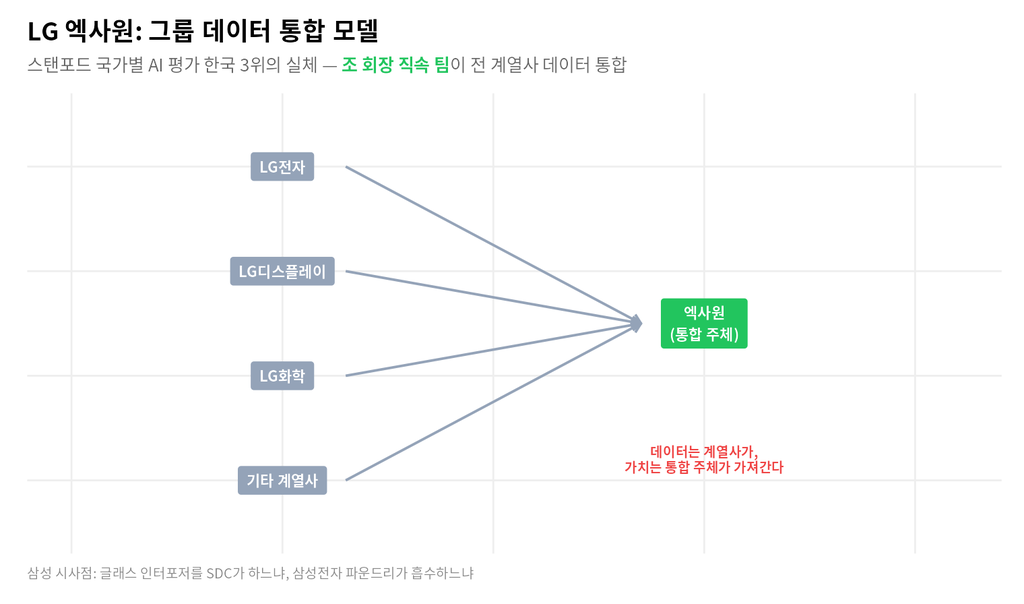

LG 엑사원 모델 — 그룹 통합 주체 vs 데이터 공급자

글래스 인터포저, 누가 주체가 되는가

LG 모델은 양날의 검을 보여준다. **통합하면 강력하지만, 개별 계열사는 데이터 공급자로 전락**한다.

SDC가 보유한 자산 — 대면적 글래스 핸들링, TGV(Through-Glass Via), 패널레벨 패키징, 응력·복굴절 측정 — 은 어드밴스드 패키징(Tech Deep Dive #3 참조)에 그대로 쓰인다. 문제는 **그 자산으로 SDC가 사업 주체가 되느냐, 삼성전자 파운드리(DS)가 흡수하느냐**다.

그룹 차원의 교통정리가 없으면, SDC는 LG디스플레이처럼 **"자산은 제공하되 주체는 못 되는"** 위치에 놓일 수 있다. **이것이 시나리오 2(Glass 전환)의 최대 실행 리스크다 — 기술이 아니라 거버넌스.**

## V. 시나리오 업데이트: 5월 대비 무엇이 바뀌었나

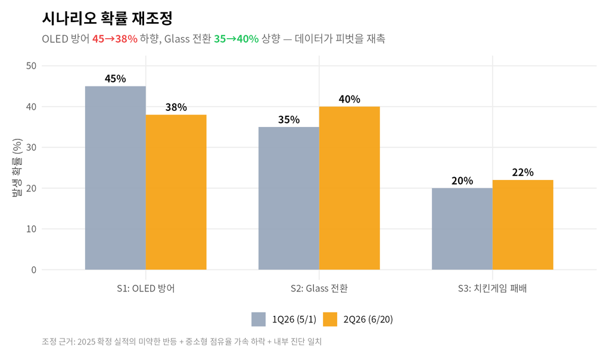

시나리오 확률 업데이트 (1Q26 → 2Q26)

| 변화 | 1Q26 | 2Q26 | 근거 |
| --- | --- | --- | --- |
| **S1 OLED 방어** | 45% | **38%** ↓ | 2025 반등이 구조개선 아님 확인, 중소형 -14%p 가속 |
| **S2 Glass 전환** | 35% | **40%** ↑ | AI 캐펙스 슈퍼사이클 가속, 어드밴스드 패키징 수요 폭증 |
| **S3 치킨게임 패배** | 20% | **22%** ↑ | 그룹 통합 리스크(LG 모델) 신규 반영 |

핵심 결론: "느린 죽음 vs 산업 탈출"

두 달 전 세 갈래 길은 여전히 유효하다. 그러나 데이터는 **중앙값을 S1에서 S2로 밀고 있다.**

1. **OLED 단독 경로 = 느린 죽음** — 생존하되 매년 작아진다. 내부 임원도 "5년 더 어렵다"로 동의.
2. **Glass/패키징 전환 = 산업 탈출** — AI 밸류체인 편입. 단, 고객(세트→파운드리)·신뢰성 기준·경쟁자(TSMC·AMAT)가 완전히 바뀐다.
3. **진짜 리스크는 기술이 아니라 거버넌스** — SDC가 주체가 되느냐, DS가 흡수하느냐.

**유리를 다루는 물리학은 변하지 않는다.** LCD→OLED 전환을 만든 그 역량이, OLED→Glass Substrate 전환의 무기다. 문제는 속도와 주체다.

## 에필로그: 답안지를 받아 든 6월

5월에 그린 지도가 6월의 답안지와 맞았다. 외부 데이터와 내부 육성이 같은 그림을 가리킬 때, 그 진단은 더 이상 가설이 아니다.

남은 질문은 하나다 — **삼성디스플레이는 느린 죽음의 고리 안에서 더 빨리 뛸 것인가, 아니면 고리 밖으로 나갈 것인가.** 그리고 그 결정을, 임기에 묶인 경영진이 내릴 수 있는가.

다음 보고서(3Q26)에서는 아산 8.6세대 IT OLED 양산 실적과 글래스 인터포저 사업화 신호를 추적한다.

*Alpha Hunter Sector Report · 2026.06.20 · Nakcho Choi × Claude Opus 4.8*

*면책: 이 프로젝트는 가상 투자 시뮬레이션 목적으로 작성되었습니다. 실제 투자 권유가 아닙니다. 내부 세미나 인용은 산업 동향 분석 목적이며, 특정 발언자를 식별하지 않습니다.*